# Learn R from MarinStatsLectures

This is an [R Youtube Lectures](https://www.youtube.com/watch?v=riONFzJdXcs&list=PLqzoL9-eJTNBDdKgJgJzaQcY6OXmsXAHU) Notebook.

### 1.1 RStudio

```r
x<-1:5
y<-6:10
plot(x,y)
```

[output not shown]

### 1.2 Install R and RStudio

Download [R](http://www.r-project.org) first.

Then install [RStudio]

### 1.3 Getting Started

0:00:20 How to assign values to an object in R: 2 different ways

```r
y=12
x<- 11
print(y)
```

```
[1] 12
```

```r
x
```

```
[1] 11
```

easy to overwrite.

0:01:46 How to use “ls” command to see what is stored in R (memory)

```r
ls()
```

```
[1] "x" "y"
```

0:01:57 How remove an object using “rm” command

```r
rm(y)
y
```

```
Error: object 'y' not found
```

0:02:52 How to assign character values to objects in R

```r
myName<-"Eric"
myName
```

```
[1] "Eric"
```

### 1.4 Vectors, Matrices

0:00:29 how to create vectors in R for both numbers or objects using the “c” or “concatenate” command

```r
x1 <- c(1,3,4,7,9)
x1
```

```
[1] 1 3 4 7 9
```

```r
gender <- c("male","female")
gender
```

```
[1] "male"   "female"
```

0:01:09 how to create a sequence of integer values in R using the colon (:)

```r
x2 <- c(2:7)
x2
```

```
[1] 2 3 4 5 6 7
```

0:01:20 how to use “seq” command in R to create sequences

```r
seq(from=1,to=7,by=2)
```

```
[1] 1 3 5 7
```

```r
seq(1,10,3)
```

```
[1]  1  4  7 10
```

0:01:55 how to use “rep” command in R to create a vector of repeated numbers or characters

```r
rep(1, times=10)
```

```
 [1] 1 1 1 1 1 1 1 1 1 1
```

```r
rep("Eric",5)
```

```
[1] "Eric" "Eric" "Eric" "Eric" "Eric"
```

```r
rep(1:3,5)
```

```
 [1] 1 2 3 1 2 3 1 2 3 1 2 3 1 2 3
```

0:03:34 how to perform basic arithmetic functions on the elements of one vector in R

```r
x<-1:5
x+10
x*3
```

[output not shown]

0:04:02 how to preform arithmetic functions on the corresponding elements of two vectors in R

```r
y<-c(2,3,4,7,10)
x+y
```

[output not shown]

```r
x*y
```

[output not shown]

0:04:59 how to extract elements of a vector using square brackets[] in R

```r
y
```

```
[1]  2  3  4  7 10
```

```r
y[3]
```

```
[1] 4
```

```r
y[-3]
```

```
[1]  2  3  7 10
```

```r
y[1:3]
```

```
[1] 2 3 4
```

```r
y[c(1,5)]
```

```
[1]  2 10
```

```r
y[-c(1,5)]
```

```
[1] 3 4 7
```

```r
y[y>5]
```

```
[1]  7 10
```

0:06:08 how to create a matrix using “matrix” command in R

```r
matrix(c(1,2,3,4,5,6,7,8,9),nrow=3,byrow=TRUE)
```

```
     [,1] [,2] [,3]
[1,]    1    2    3
[2,]    4    5    6
[3,]    7    8    9
```

```r
matrix(c(1,2,3,4,5,6,7,8,9),nrow=3,byrow=FALSE)
```

```
     [,1] [,2] [,3]
[1,]    1    4    7
[2,]    2    5    8
[3,]    3    6    9
```

```r
matrix(c(1,2,3,4,5,6,7,8,9),nrow=3)
```

```
     [,1] [,2] [,3]
[1,]    1    4    7
[2,]    2    5    8
[3,]    3    6    9
```

```r
matrix(c(1,2,3,4,5,6,7,8,9,10),nrow=2)
```

```
     [,1] [,2] [,3] [,4] [,5]
[1,]    1    3    5    7    9
[2,]    2    4    6    8   10
```

```r
mat <- matrix(c(1,2,3,4,5,6,7,8,9),nrow=3,byrow=TRUE)
```

0:06:21 how to set the number of rows and columns in a matrix using “nrow” and “byrow” commands in R

0:07:05 how to use the square brackets to extract certain elements from a matrix in R

```r
mat[1,2]
```

```
[1] 2
```

```r
mat[3,2]
```

```
[1] 8
```

```r
mat[c(1,3),2]
```

```
[1] 2 8
```

```r
mat[,2]
```

```
[1] 2 5 8
```

0:08:06 how to perform element-wise arithmetic functions in a matrix in R

```r
mat^2
```

```
     [,1] [,2] [,3]
[1,]    1    4    9
[2,]   16   25   36
[3,]   49   64   81
```

### 1.5 Import csv

```r
LungCapData<-read.delim(file.choose(),header=T)
LungCapData
```

| LungCap | Age | Height | Smoke | Gender | Caesarean |
| --- | --- | --- | --- | --- | --- |
| 6.475 | 6 | 62.1 | no | male | no |
| 10.125 | 18 | 74.7 | yes | female | no |
| 9.550 | 16 | 69.7 | no | female | yes |
| 11.125 | 14 | 71.0 | no | male | no |
| 4.800 | 5 | 56.9 | no | male | no |
| 6.225 | 11 | 58.7 | no | female | no |
| 4.950 | 8 | 63.3 | no | male | yes |
| 7.325 | 11 | 70.4 | no | male | no |
| 8.875 | 15 | 70.5 | no | male | no |
| 6.800 | 11 | 59.2 | no | male | no |

[output cut: 715 more lines]

### 1.6 Working with data in R

```r
dim(LungCapData)
```

```
[1] 725   6
```

```r
names(LungCapData)
```

```
[1] "LungCap"   "Age"       "Height"    "Smoke"
[5] "Gender"    "Caesarean"
```

```r
mode(LungCapData)
```

```
[1] "list"
```

```r
class(LungCapData)
```

```
[1] "data.frame"
```

```r
summary(LungCapData)
```

```
    LungCap            Age            Height      Smoke
 Min.   : 0.507   Min.   : 3.00   Min.   :45.30   no :648
 1st Qu.: 6.150   1st Qu.: 9.00   1st Qu.:59.90   yes: 77
 Median : 8.000   Median :13.00   Median :65.40
 Mean   : 7.863   Mean   :12.33   Mean   :64.84
 3rd Qu.: 9.800   3rd Qu.:15.00   3rd Qu.:70.30
 Max.   :14.675   Max.   :19.00   Max.   :81.80
    Gender    Caesarean
 female:358   no :561
 male  :367   yes:164
```

```r
head(LungCapData)
```

|  | LungCap | Age | Height | Smoke | Gender | Caesarean |
| --- | --- | --- | --- | --- | --- | --- |
| 1 | 6.475 | 6 | 62.1 | no | male | no |
| 2 | 10.125 | 18 | 74.7 | yes | female | no |
| 3 | 9.550 | 16 | 69.7 | no | female | yes |
| 4 | 11.125 | 14 | 71.0 | no | male | no |
| 5 | 4.800 | 5 | 56.9 | no | male | no |
| 6 | 6.225 | 11 | 58.7 | no | female | no |

```r
tail(LungCapData,10)
```

|  | LungCap | Age | Height | Smoke | Gender | Caesarean |
| --- | --- | --- | --- | --- | --- | --- |
| 716 | 8.725 | 19 | 68.4 | no | female | no |
| 717 | 7.075 | 11 | 66.7 | no | male | yes |
| 718 | 8.825 | 16 | 71.3 | yes | female | no |
| 719 | 7.175 | 17 | 68.8 | no | male | yes |
| 720 | 7.325 | 9 | 66.3 | no | male | no |
| 721 | 5.725 | 9 | 56.0 | no | female | no |
| 722 | 9.050 | 18 | 72.0 | yes | male | yes |
| 723 | 3.850 | 11 | 60.5 | yes | female | no |
| 724 | 9.825 | 15 | 64.9 | no | female | no |
| 725 | 7.100 | 10 | 67.7 | no | male | no |

```r
LungCapData[c(10,20,30),]
```

|  | LungCap | Age | Height | Smoke | Gender | Caesarean |
| --- | --- | --- | --- | --- | --- | --- |
| 10 | 6.800 | 11 | 59.2 | no | male | no |
| 20 | 9.525 | 14 | 70.6 | no | female | no |
| 30 | 10.475 | 18 | 72.0 | yes | female | no |

```r
LungCapData[21:24,]
```

|  | LungCap | Age | Height | Smoke | Gender | Caesarean |
| --- | --- | --- | --- | --- | --- | --- |
| 21 | 3.975 | 6 | 57.3 | no | male | no |
| 22 | 5.325 | 8 | 59.7 | no | female | no |
| 23 | 10.025 | 16 | 72.4 | no | male | no |
| 24 | 8.725 | 11 | 68.0 | no | male | yes |

```r
LungCapData[-c(4:722),]
```

|  | LungCap | Age | Height | Smoke | Gender | Caesarean |
| --- | --- | --- | --- | --- | --- | --- |
| 1 | 6.475 | 6 | 62.1 | no | male | no |
| 2 | 10.125 | 18 | 74.7 | yes | female | no |
| 3 | 9.550 | 16 | 69.7 | no | female | yes |
| 723 | 3.850 | 11 | 60.5 | yes | female | no |
| 724 | 9.825 | 15 | 64.9 | no | female | no |
| 725 | 7.100 | 10 | 67.7 | no | male | no |

### 1.7 Working with Data in R

```r
mean(LungCapData$Age)

attach(LungCapData)
max(Age)
class(Age)
class(Smoke)
levels(Gender)
```

[output not shown]

```r
x <- c(0,1,1,1,0,0,0,0)
class(x)
```

```
[1] "numeric"
```

```r
summary(x)
```

```
   Min. 1st Qu.  Median    Mean 3rd Qu.    Max.
  0.000   0.000   0.000   0.375   1.000   1.000
```

```r
x<-as.factor(x)
class(x)
```

```
[1] "factor"
```

```r
summary(x)
```

```
0 1
5 3
```

### 1.8 subsetting Date with square brackets

```r
Age[11:14]
```

```
[1] 19 17 12 10
```

```r
mean(Age[Gender=="female"])
```

```
[1] 12.44972
```

```r
mean(Age[Gender=="male"])
```

```
[1] 12.20708
```

```r
mean(Age)
```

```
[1] 12.3269
```

```r
MaleOver15 <- LungCapData[Gender=="male" & Age>15,]
summary(MaleOver15)
```

```
    LungCap           Age            Height      Smoke
 Min.   : 6.45   Min.   :16.00   Min.   :66.20   no :73
 1st Qu.:10.28   1st Qu.:16.00   1st Qu.:71.10   yes:16
 Median :11.07   Median :17.00   Median :73.50
 Mean   :11.10   Mean   :17.31   Mean   :73.64
 3rd Qu.:12.12   3rd Qu.:18.00   3rd Qu.:75.90
 Max.   :14.68   Max.   :19.00   Max.   :81.80
    Gender   Caesarean
 female: 0   no :65
 male  :89   yes:24
```

### 1.9 Logic

```r
Age[1:5]
```

```
[1]  6 18 16 14  5
```

```r
temp1 <- Age>15
temp1[1:5]
```

```
[1] FALSE  TRUE  TRUE FALSE FALSE
```

```r
temp2 <- as.numeric(Age>15)
temp2[1:5]
```

```
[1] 0 1 1 0 0
```

0:01:55 how to use multiple logical statements within an R command to have a logical vector answering multiple questions (step by step example)

```r
FemSmoke <- Gender=="female" & Smoke=="yes"
FemSmoke[1:5]
```

```
[1] FALSE  TRUE FALSE FALSE FALSE
```

0:02:50 how to attach vectors or matrices in a column-wise fashion using the “cbind” command or in a row-wise fashion using the “rbind” command in R

```r
MoreData <- cbind(LungCapData, FemSmoke)
MoreData[1:5,]
```

|  | LungCap | Age | Height | Smoke | Gender | Caesarean | FemSmoke |
| --- | --- | --- | --- | --- | --- | --- | --- |
| 1 | 6.475 | 6 | 62.1 | no | male | no | FALSE |
| 2 | 10.125 | 18 | 74.7 | yes | female | no | TRUE |
| 3 | 9.550 | 16 | 69.7 | no | female | yes | FALSE |
| 4 | 11.125 | 14 | 71.0 | no | male | no | FALSE |
| 5 | 4.800 | 5 | 56.9 | no | male | no | FALSE |

```r
rm(list=ls())
```

### 1.10 Working Directory

```r
getwd()
```

```
[1] "C:/Users/EricQiu/Documents/R"
```

### 1.12 installing packages

```r
help("install.packages")
```

### 2.1 Bar Charts and Pie Charts

```r
table(Gender)
```

```
Gender
female   male
   358    367
```

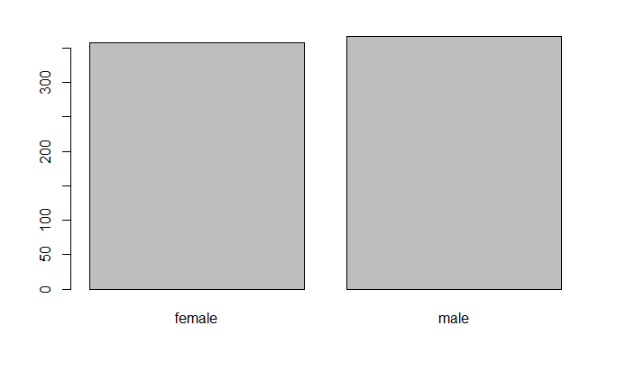

```r
count<-table(Gender)
pt<-table(Gender)/725
barplot(count)
```

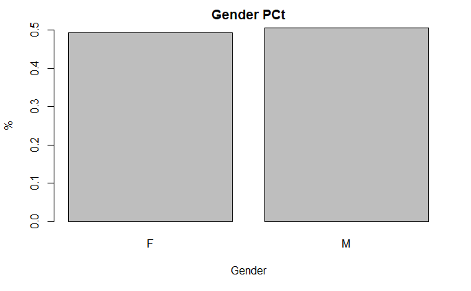

```r
barplot(pt, main="Gender PCt", xlab="Gender", ylab="%", names.arg = c("F","M"))
```

Modifying Pie Chart in R:

```r
pie(count)
```

[output not shown]

### 2.2 Boxplot

A boxplot is for summarizing the distribution of a numeric variable

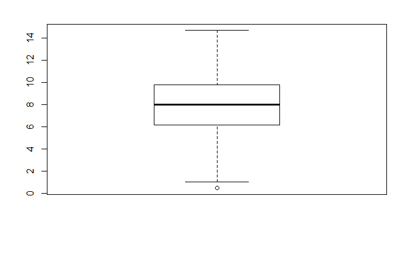

```r
boxplot(LungCap)
```

```r
quantile(LungCap,probs=c(0,0.25,0.5,0.75,1))
```

```
    0%    25%    50%    75%   100%
 0.507  6.150  8.000  9.800 14.675
```

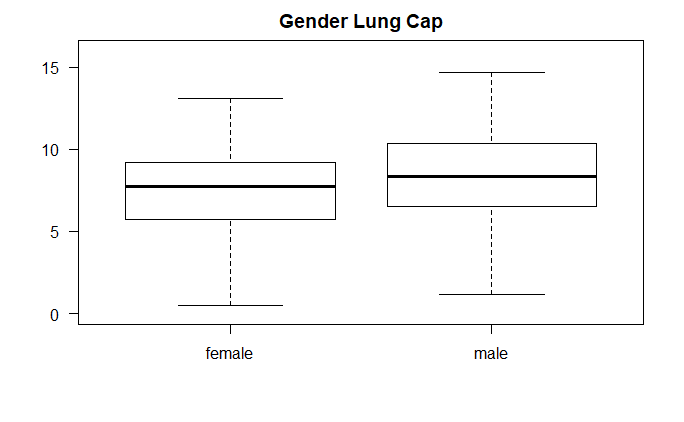

```r
boxplot(LungCap~Gender,main="Gender Lung Cap", ylim=c(0,16), las=1)
```

### 2.3 Stratifed boxplots

relationship between a categorical variable and a numeric variable, within strata or groups defined by a third categorical variable

```r
AgeGroups<-cut(Age, breaks=c(0,13,15,17,25), labels = c("<13","14/15","16/17","18+"))
Age[1:5]
```

```
[1]  6 18 16 14  5
```

```r
AgeGroups[1:5]
```

```
[1] <13   18+   16/17 14/15 <13
Levels: <13 14/15 16/17 18+
```

```r
levels(AgeGroups)
```

```
[1] "<13"   "14/15" "16/17" "18+"
```

The Smoking effiect is confounded with the age efffect on average, smokers are older than non-smokers, and older children have bigger lung capacities

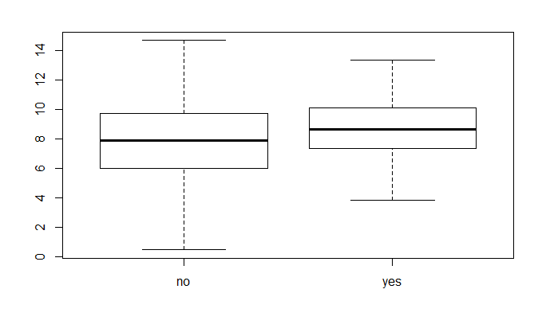

```r
boxplot(LungCap~Smoke)
```

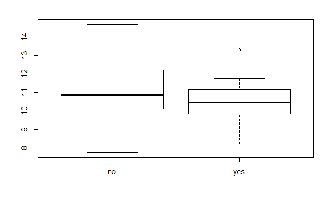

```r
boxplot(LungCap[Age>=18]~Smoke[Age>=18])
```

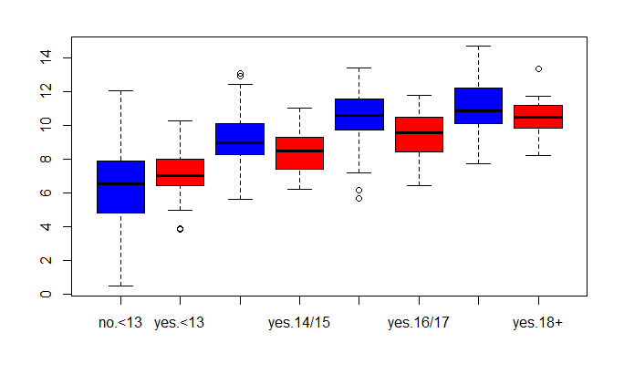

```r
boxplot(LungCap~Smoke*AgeGroups,col=c(4,2))
```

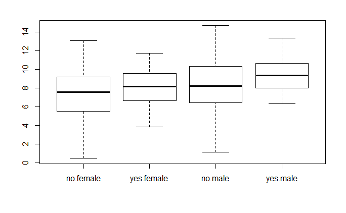

```r
boxplot(LungCap~Smoke*Gender)
```

### 2.3 Histgrams

for summarizing the distribution of a numeric variable

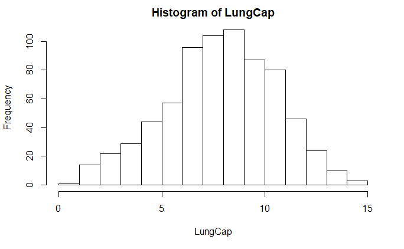

```r
hist(LungCap)
```

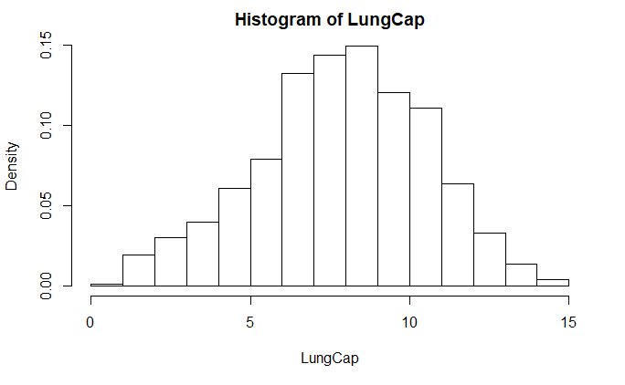

```r
hist(LungCap, freq = F)
```

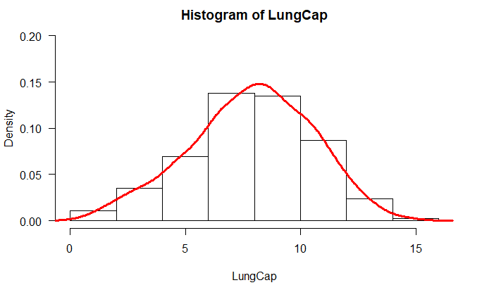

```r
hist(LungCap, prob = T, ylim=c(0,0.20), breaks=seq(0,16,2), las=1)
lines(density(LungCap),col=2,lwd=3)
```

### 2.4 Stem and leaf plots

```r
femalelungecap<-LungCap[Gender=="female"]
stem(femalelungecap)
```

```
  The decimal point is at the |

   0 | 5
   1 | 0135689
   2 | 0033456777789999
   3 | 0122457788999999
   4 | 012333344555556666677777899
   5 | 0000122222334466666777778999
   6 | 000111111122222222233345555556666667777777788888999999
   7 | 000123334444444445555666667778888888999999
   8 | 000000001111122222333333444444555556666666666777777888888888899
   9 | 0000000011122223333344455556666777788888999999
  10 | 000011111222334445555666777778899
  11 | 00111223556678888
  12 | 1222479
  13 | 1
```

```r
stem(femalelungecap,scale=2)
```

```
  The decimal point is at the |

   0 | 5
   1 | 013
   1 | 5689
   2 | 00334
   2 | 56777789999
   3 | 01224
   3 | 57788999999
   4 | 012333344
   4 | 555556666677777899
   5 | 00001222223344
   5 | 66666777778999
   6 | 00011111112222222223334
   6 | 5555556666667777777788888999999
   7 | 00012333444444444
   7 | 5555666667778888888999999
   8 | 000000001111122222333333444444
   8 | 555556666666666777777888888888899
   9 | 00000000111222233333444
   9 | 55556666777788888999999
  10 | 00001111122233444
  10 | 5555666777778899
  11 | 00111223
  11 | 556678888
  12 | 12224
  12 | 79
  13 | 1
```

### 2.5 Stacked barcharts, clustered barcharts, mosaic plot

examing the relationship between 2 categorical variables

```r
table1 <- table(Smoke,Gender)
table1
```

```
     Gender
Smoke female male
  no     314  334
  yes     44   33
```

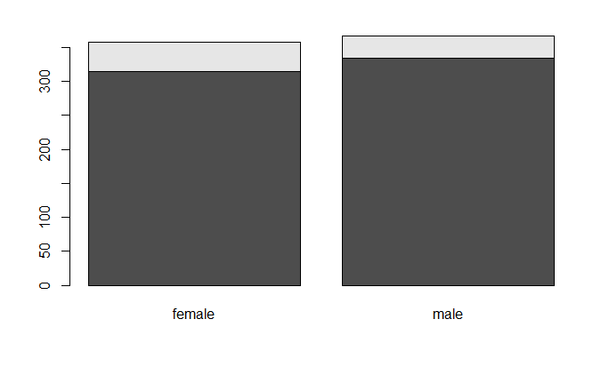

```r
barplot(table1)
```

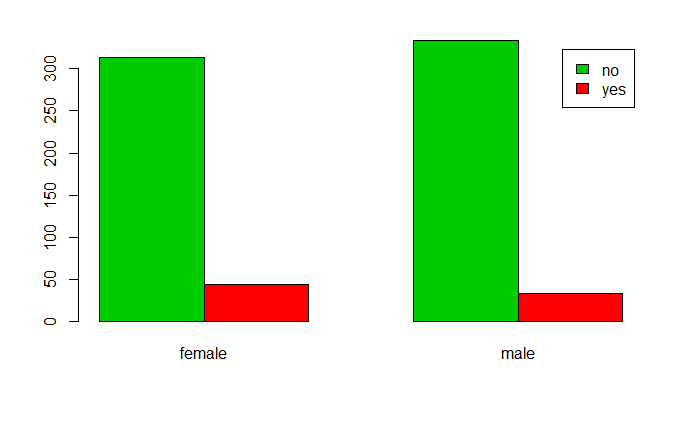

```r
barplot(table1,beside = T, legend.text=T, col=c(3,2))
```

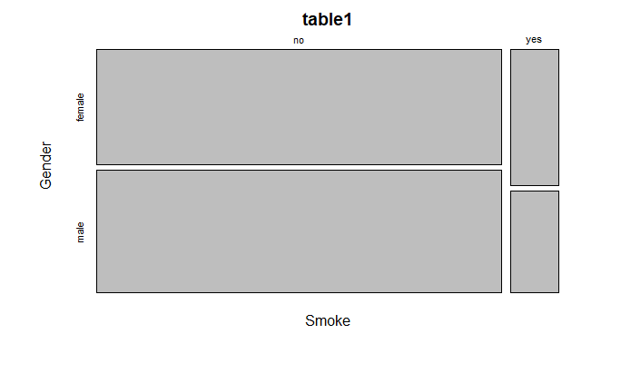

```r
mosaicplot(table1)
```

### 2.6 Scatterplots

examing the relationship between two numerical variables

Pearson’s correlation is used to examine the strength of the linear relationship between the 2 numeric variables

```r
cor(Age,Height)
```

```
[1] 0.8357368
```

```r
plot(Age, Height)
abline(lm(Height~Age), col=4, lwd=3)
```

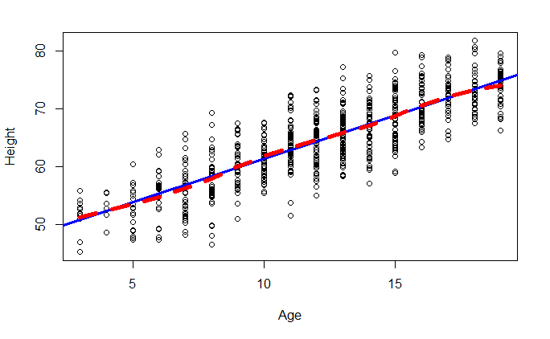

```r
lines(smooth.spline(Age, Height), lty=2, lwd=5, col=2)
```

### 2.7 numerical summary

```r
table(Smoke)
```

```
Smoke
 no yes
648  77
```

```r
table(Smoke)/length(Smoke)
```

```
Smoke
       no       yes
0.8937931 0.1062069
```

```r
table(Smoke,Gender)
```

```
     Gender
Smoke female male
  no     314  334
  yes     44   33
```

```r
mean(LungCap, trim=0.10)
```

```
[1] 7.938081
```

```r
median(LungCap)
```

```
[1] 8
```

```r
var(LungCap)
```

```
[1] 7.086288
```

```r
sd(LungCap)
```

```
[1] 2.662008
```

```r
sqrt(var(LungCap))
```

```
[1] 2.662008
```

```r
sd(LungCap)^2
```

```
[1] 7.086288
```

```r
range(LungCap)
```

```
[1]  0.507 14.675
```

```r
quantile(LungCap,probs = c(0.10,0.50,0.90))
```

```
   10%    50%    90%
 4.250  8.000 11.205
```

```r
cor(LungCap,Age)
```

```
[1] 0.8196749
```

```r
cor(LungCap,Age,method = "spearman")
```

```
[1] 0.8172464
```

```r
cov(LungCap,Age)
```

```
[1] 8.738289
```

```r
var(LungCap,Age)
```

```
[1] 8.738289
```

```r
summary(LungCap)
```

```
   Min. 1st Qu.  Median    Mean 3rd Qu.    Max.
  0.507   6.150   8.000   7.863   9.800  14.675
```

### 3.1 Binomial Distribution

0:00:10 introducing the binomial random variable used in this video and its characteristics choose(n,k)

```r
choose(5,0)
```

```
[1] 1
```

```r
choose(5,1)
```

```
[1] 5
```

```r
choose(5,2)
```

```
[1] 10
```

```r
choose(5,3)
```

```
[1] 10
```

```r
choose(5,4)
```

```
[1] 5
```

```r
choose(5,5)
```

```
[1] 1
```

```r
choose(20,3)
```

```
[1] 1140
```

X is binomially distributed with n=20 trials and p=1/6 probability of success X ~ Bin (n=20,p=1/6)

0:00:43 how to use the “dbinom” command in R to calculate probability for the binomial random variable **dbinom** is used to find values for the probability density function of X, f(x)

P(X=3)

```r
dbinom(x=3,size=20,prob=1/6)
```

```
[1] 0.2378866
```

```r
choose(20,3)*(1/6)^3*(1-1/6)^(20-3)
```

```
[1] 0.2378866
```

P(x=0) & p(x=1) & p(x=2) & p(x=3)

```r
dbinom(x=0:3,size=20,prob=1/6)
```

```
[1] 0.02608405 0.10433621 0.19823881 0.23788657
```

```r
dbinom(x=0:1,size=20,prob=1/6)
```

```
[1] 0.02608405 0.10433621
```

P(x<=3)

```r
sum(dbinom(x=0:3,size=20,prob=1/6))
```

```
[1] 0.5665456
```

```r
sum(dbinom(x=0:1,size=20,prob=1/6))
```

```
[1] 0.1304203
```

0:02:45 how to calculate cumulative probabilities in R for the binomial random variable using the “pbinom” command

```r
pbinom(q=3,size = 20, prob=1/6,lower.tail = T)
```

```
[1] 0.5665456
```

“dbinom” find values for the probability *density* function of X, f(x) “pbinom” gives values for the probability *distribution* function of X, F(x) “rbinom” take a *random* sample from a binomial dist.

“qbinom” find *quantiles* for a binomial dis.

### 3.2 Poisson Distribution

the number of **discrete events or occurrences** over a specified **interval or continumm**(time, length, distance, etc.)

lambda= # occurences / specified interval expected value, mean, lambda the same things.

checkout line, lambda=10 customer per 15 min interval. outcome, discrete outcomes, x=0,1,2,3…infinite

x follows a poisson distribution with a known rate of lambda=7 X ~ poisson(lambda=7)

```r
dpois(x=4, lambda = 7)
```

```
[1] 0.09122619
```

```r
7^4*exp(-7)/factorial(4)
```

```
[1] 0.09122619
```

```r
dpois(x=0:4, lambda = 7)
```

```
[1] 0.000911882 0.006383174 0.022341108 0.052129252 0.091226192
```

```r
sum(dpois(x=0:4, lambda = 7))
```

```
[1] 0.1729916
```

```r
ppois(q=4, lambda = 7,lower.tail = T)
```

```
[1] 0.1729916
```

### 3.3 Normally Distribution

X is normally distributed with a known mean of 75 and standard deviation of 5 P(X<=70)

```r
pnorm(q=70, mean=75, sd=5, lower.tail = T)
```

```
[1] 0.1586553
```

P(Z>1)

```r
pnorm(q=1,mean=0,sd=1, lower.tail = F)
```

```
[1] 0.1586553
```

```r
qnorm(p=0.25, mean=75, sd=5,lower.tail = T)
```

```
[1] 71.62755
```

```r
qnorm(p=0.5, mean=75, sd=5,lower.tail = T)
```

```
[1] 75
```

```r
qnorm(p=0.75, mean=75, sd=5,lower.tail = T)
```

```
[1] 78.37245
```

```r
qnorm(p=0.90, mean=75, sd=5,lower.tail = T)
```

```
[1] 81.40776
```

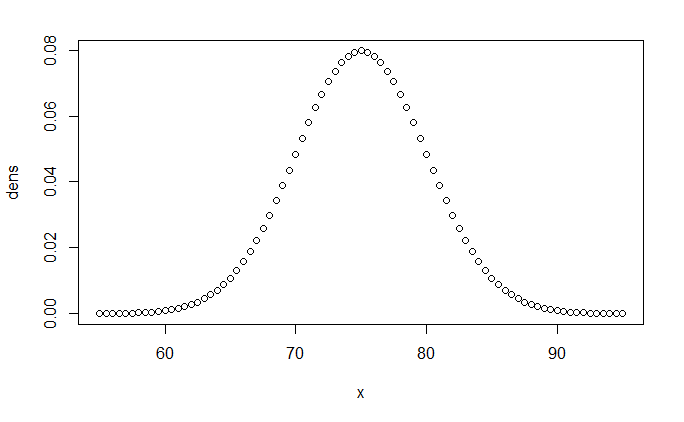

```r
x<-seq(55,95,0.5)
dens<-dnorm(x,mean=75,sd=5)
plot(x,dens)
```

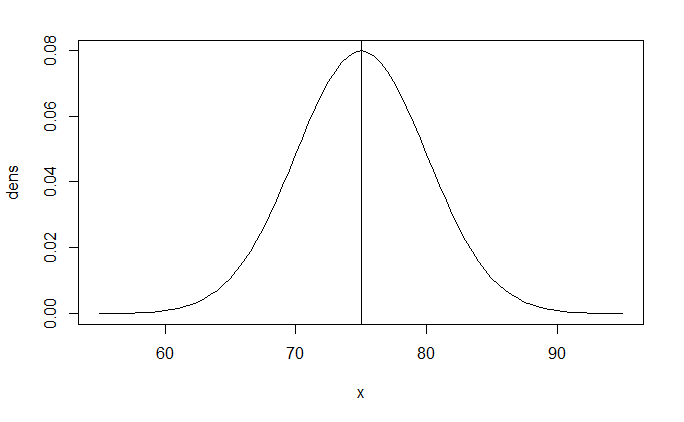

```r
plot(x,dens,type="l")
abline(v=75)
```

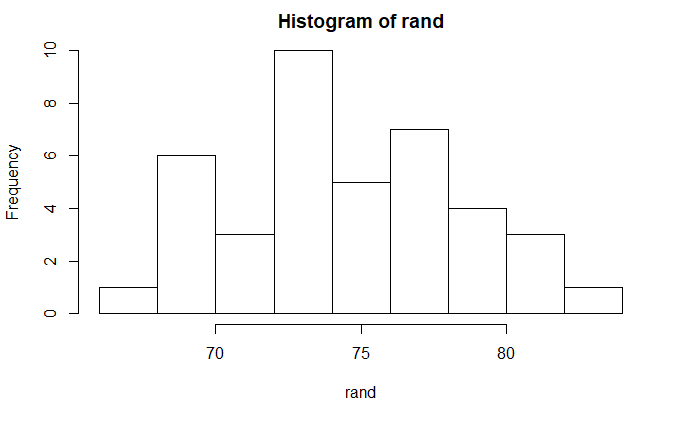

```r
rand<- rnorm(n=40, mean=75, sd=5)
hist(rand)
```

### 3.4 t Distribution and t Scores

these can be used to find p-values or critical values for constructing confidence intervals for statistics that follow a t-distribution

t follows a t-dis, with mean=0, sd=1 and 25 degrees of freedom. P(t>2.3)

```r
pt(q=2.3, df=25, lower.tail=F)
```

```
[1] 0.01503675
```

```r
pt(q=2.3, df=25, lower.tail=F)+pt(q=-2.3, df=25, lower.tail=T)
```

```
[1] 0.03007351
```

find t value for 95% confidence

```r
qt(p=0.025, df=25, lower.tail = T)
```

```
[1] -2.059539
```

### 4.1 one-sample t Test

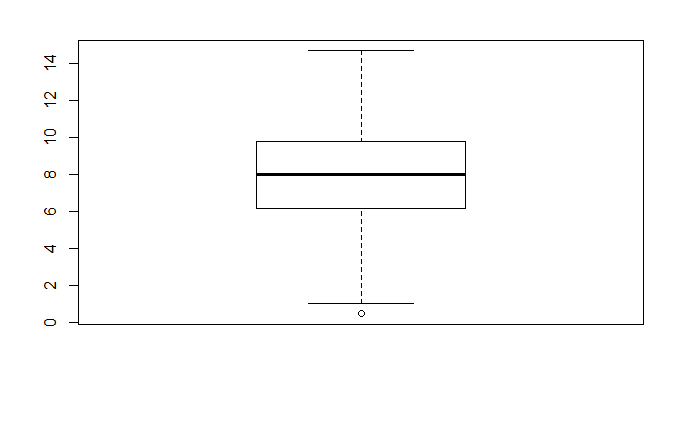

```r
boxplot(LungCap)
```

```r
summary(LungCap)
```

```
   Min. 1st Qu.  Median    Mean 3rd Qu.    Max.
  0.507   6.150   8.000   7.863   9.800  14.675
```

Ho: mu>=8, Ha:mu<8 one-sided 95% confidence interval for mu

```r
t.test(LungCap, mu=8, alternative = "less", conf.level = 0.95)
```

```
    One Sample t-test

data:  LungCap
t = -1.3842, df = 724, p-value = 0.08336
alternative hypothesis: true mean is less than 8
95 percent confidence interval:
     -Inf 8.025974
sample estimates:
mean of x
 7.863148
```

two-sided

```r
t.test(LungCap, mu=8, alt = "two.sided", conf = 0.95)
```

```
    One Sample t-test

data:  LungCap
t = -1.3842, df = 724, p-value = 0.1667
alternative hypothesis: true mean is not equal to 8
95 percent confidence interval:
 7.669052 8.057243
sample estimates:
mean of x
 7.863148
```

```r
TEST<-t.test(LungCap, mu=8,  conf.level = 0.99)
TEST
```

```
    One Sample t-test

data:  LungCap
t = -1.3842, df = 724, p-value = 0.1667
alternative hypothesis: true mean is not equal to 8
99 percent confidence interval:
 7.607816 8.118479
sample estimates:
mean of x
 7.863148
```

```r
TEST$p.value
```

```
[1] 0.1667108
```

```r
TEST$conf.int
```

```
[1] 7.607816 8.118479
attr(,"conf.level")
[1] 0.99
```

### 4.2 two-sample t Test

these are ways of examing the relationship between a numeric outcome variable (Y) and a categorical explanatory variable (X, with 2 levels).

Ho : mean lung cap of sokers = of non somkers two-sided test assume non-equal variance

```r
t.test(LungCap~Smoke, mu=0, alt = "two.sided", conf = 0.95, var.eq=F, paired=F)
```

```
    Welch Two Sample t-test

data:  LungCap by Smoke
t = -3.6498, df = 117.72, p-value = 0.0003927
alternative hypothesis: true difference in means is not equal to 0
95 percent confidence interval:
 -1.3501778 -0.4003548
sample estimates:
 mean in group no mean in group yes
         7.770188          8.645455
```

```r
#same default value
t.test(LungCap~Smoke)
```

```
    Welch Two Sample t-test

data:  LungCap by Smoke
t = -3.6498, df = 117.72, p-value = 0.0003927
alternative hypothesis: true difference in means is not equal to 0
95 percent confidence interval:
 -1.3501778 -0.4003548
sample estimates:
 mean in group no mean in group yes
         7.770188          8.645455
```

```r
var(LungCap[Smoke=="yes"])
```

```
[1] 3.545292
```

```r
var(LungCap[Smoke=="no"])
```

```
[1] 7.431694
```

### 5.1 Linear Regression

Model the relationship between Age and Lung Capacity

```r
cor(Age, LungCap)
```

```
[1] 0.8196749
```

```r
mod<-lm(LungCap~Age)
summary(mod)
```

```
Call:
lm(formula = LungCap ~ Age)

Residuals:
    Min      1Q  Median      3Q     Max
-4.7799 -1.0203 -0.0005  0.9789  4.2650

Coefficients:
            Estimate Std. Error t value Pr(>|t|)
(Intercept)  1.14686    0.18353   6.249 7.06e-10 ***
Age          0.54485    0.01416  38.476  < 2e-16 ***
---
Signif. codes:  0 ‘***’ 0.001 ‘**’ 0.01 ‘*’ 0.05 ‘.’ 0.1 ‘ ’ 1

Residual standard error: 1.526 on 723 degrees of freedom
Multiple R-squared:  0.6719,    Adjusted R-squared:  0.6714
F-statistic:  1480 on 1 and 723 DF,  p-value: < 2.2e-16
```

```r
attributes(mod)
```

```
$names
 [1] "coefficients"  "residuals"     "effects"       "rank"
 [5] "fitted.values" "assign"        "qr"            "df.residual"
 [9] "xlevels"       "call"          "terms"         "model"

$class
[1] "lm"
```

```r
mod$coefficients
```

```
(Intercept)         Age
  1.1468578   0.5448484
```

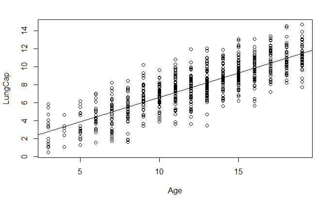

```r
plot(Age,LungCap)
abline(mod)
```